# 4b. Imputacja metodą najbliższego sąsiada

# 1 Wczytanie potrzebnych pakietów

**R**

```r
library(simputation)
library(VIM)
```

**Python**

```python
import numpy as np
import pandas as pd
from sklearn.preprocessing import MinMaxScaler, PolynomialFeatures, StandardScaler
from sklearn.neighbors import NearestNeighbors
from sklearn.linear_model import LinearRegression
from sklearn.impute import KNNImputer
import matplotlib.pyplot as plt
import gower
```

# 2 Krok 0 – dane i braki

Dane `data6-wydatki.csv`: 1000 gospodarstw domowych, miesięczne wydatki (`wydatki`) z brakami i ich prawdziwa wartość (`wydatki_prawda`). Zmienne `wzrost`, `czas_wywiadu`, `nr_ankietera` i `miesiac_urodzenia` nie są związane ani z wydatkami, ani z brakami.

**R**

Wczytanie danych i odsetek braków

```r
dane <- read.csv("../../data/data6-wydatki.csv", stringsAsFactors = TRUE)
## wydatki jako liczby rzeczywiste (VIM::kNN() obcina średnią do liczby całkowitej)
dane$wydatki <- as.numeric(dane$wydatki)
braki <- is.na(dane$wydatki)
mean(braki)
```

```
[1] 0.334
```

Średnia prawdziwa i średnia z respondentów

```r
mean(dane$wydatki_prawda)
```

```
[1] 5816.79
```

```r
mean(dane$wydatki, na.rm = TRUE)
```

```
[1] 5403.363
```

Czy braki zależą od dochodu i wieku?

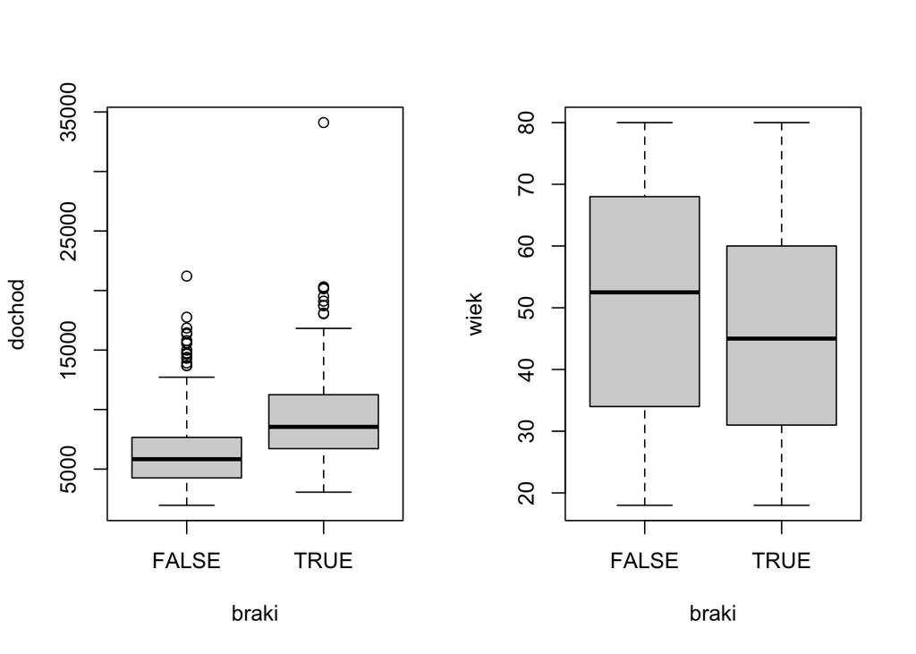

```r
par(mfrow = c(1, 2))
boxplot(dochod ~ braki, data = dane)
boxplot(wiek ~ braki, data = dane)
```

Obciążenie: średnia po imputacji minus średnia prawdziwa. Obciążenie imputacji średnią z respondentów:

```r
## obciążenie: średnia po imputacji minus średnia prawdziwa
bias <- function(y) mean(y) - mean(dane$wydatki_prawda)
bias(ifelse(braki, mean(dane$wydatki, na.rm = TRUE), dane$wydatki))
```

```
[1] -413.4266
```

**Python**

Wczytanie danych i odsetek braków

```python
dane = pd.read_csv("../../data/data6-wydatki.csv")
braki = dane['wydatki'].isna().to_numpy()
braki.mean()
```

```
np.float64(0.334)
```

Średnia prawdziwa i średnia z respondentów

```python
print(dane['wydatki_prawda'].mean())
```

```
5816.79
```

```python
print(dane['wydatki'].mean())
```

```
5403.3633633633635
```

Czy braki zależą od dochodu i wieku?

```python
dane.assign(brak=braki).boxplot(column=['dochod', 'wiek'], by='brak')
```

```
array([<Axes: title={'center': 'dochod'}, xlabel='brak'>,
       <Axes: title={'center': 'wiek'}, xlabel='brak'>], dtype=object)
```

[figure not shown]

```python
plt.show()
```

Obciążenie: średnia po imputacji minus średnia prawdziwa. Obciążenie imputacji średnią z respondentów:

```python
# obciążenie: średnia po imputacji minus średnia prawdziwa
def bias(y):
    return np.mean(y) - dane['wydatki_prawda'].mean()

bias(dane['wydatki'].fillna(dane['wydatki'].mean()))
```

```
np.float64(-413.42663663663734)
```

W Pythonie nie ma odpowiednika `impute_knn()`, dlatego definiujemy dwie krótkie funkcje pomocnicze.

```python
dawcy = dane[~braki]
y_dawcow = dawcy['wydatki'].to_numpy()

def nearest_donors(X, k=1):
    """Numery k najbliższych dawców każdego biorcy (zmienne przeskalowane do [0, 1], odległość miejska)."""
    X = MinMaxScaler().fit_transform(X)
    nn = NearestNeighbors(n_neighbors=k, metric='manhattan').fit(X[~braki])
    return nn.kneighbors(X[braki], return_distance=False)

def fill_missing(wartosci):
    """Wstawia wartości w miejsce braków."""
    y = dane['wydatki'].to_numpy().copy()
    y[braki] = wartosci
    return y
```

**Pytania:**

- Czym różnią się respondenci od nierespondentów pod względem dochodu i wieku?
- Dlaczego średnia z respondentów zaniża wydatki?
- Czy imputacja średnią usuwa obciążenie?

# 3 Krok 1 – najbliższy sąsiad krok po kroku

Imputujemy wydatki na podstawie jednej zmiennej: dochodu.

**R**

Pierwszy biorca i jego najbliższy dawca

```r
biorca <- which(braki)[1]
dawcy <- dane[!braki, ]
dane[biorca, c("dochod", "wiek", "liczba_osob", "wydatki_prawda")]
```

```
  dochod wiek liczba_osob wydatki_prawda
1   6200   67           1           5080
```

```r
odl <- abs(dawcy$dochod - dane$dochod[biorca])
dawcy[which.min(odl), c("dochod", "wiek", "liczba_osob", "wydatki")]
```

```
    dochod wiek liczba_osob wydatki
733   6200   28           2    5140
```

Imputacja wszystkich braków

```r
imp <- impute_knn(dane, wydatki ~ dochod, k = 1)
bias(imp$wydatki)
```

```
[1] 75.23
```

**Python**

Pierwszy biorca i jego najbliższy dawca

```python
biorca = np.flatnonzero(braki)[0]
dane.loc[biorca, ['dochod', 'wiek', 'liczba_osob', 'wydatki_prawda']]
```

```
dochod            6200
wiek                67
liczba_osob          1
wydatki_prawda    5080
Name: 0, dtype: int64
```

```python
odl = (dawcy['dochod'] - dane.loc[biorca, 'dochod']).abs()
dawcy.loc[odl.idxmin(), ['dochod', 'wiek', 'liczba_osob', 'wydatki']]
```

```
dochod         6200.0
wiek             28.0
liczba_osob       2.0
wydatki        5140.0
Name: 732, dtype: float64
```

Imputacja wszystkich braków

```python
idx = nearest_donors(dane[['dochod']], k=1)
bias(fill_missing(y_dawcow[idx[:, 0]]))
```

```
np.float64(76.68000000000029)
```

**Pytania:**

- Czym różni się dawca od biorcy poza dochodem?
- Czy średnia po imputacji jest bliżej prawdy niż średnia z respondentów?

# 4 Krok 2 – same zmienne jakościowe

Dawców szukamy tylko po płci, wykształceniu i klasie miejscowości.

**R**

Odległości Gowera pierwszego biorcy od dawców

```r
klasy <- c("plec", "wyksztalcenie", "klasa_miejsc")
table(gower::gower_dist(dane[biorca, klasy], dawcy[klasy]))
```

```
                0 0.333333333333333 0.666666666666667                 1
               39               177               317               133
```

Hot-deck w klasach i najbliższy sąsiad; liczba różnych wstawionych wartości

```r
set.seed(2025)
imp_hd <- impute_rhd(dane, wydatki ~ plec + wyksztalcenie + klasa_miejsc)
imp_nn <- impute_knn(dane, wydatki ~ plec + wyksztalcenie + klasa_miejsc, k = 1)
bias(imp_hd$wydatki)
```

```
[1] -401.77
```

```r
bias(imp_nn$wydatki)
```

```
[1] -394.17
```

```r
length(unique(imp_hd$wydatki[braki]))
```

```
[1] 207
```

```r
length(unique(imp_nn$wydatki[braki]))
```

```
[1] 24
```

**Python**

Na ilu zmiennych dawcy różnią się od pierwszego biorcy?

```python
klasy = ['plec', 'wyksztalcenie', 'klasa_miejsc']
# na ilu zmiennych dawcy różnią się od pierwszego biorcy?
(dawcy[klasy] != dane.loc[biorca, klasy]).sum(axis=1).value_counts().sort_index()
```

```
0     39
1    177
2    317
3    133
Name: count, dtype: int64
```

Hot-deck w klasach i najbliższy sąsiad; liczba różnych wstawionych wartości

```python
rng = np.random.default_rng(2025)
# losowy hot-deck w klasach
imp_hd = dane.groupby(klasy)['wydatki'].transform(
    lambda s: s.fillna(pd.Series(rng.choice(s.dropna(), len(s)), index=s.index)))
# najbliższy sąsiad (k = 1); zmienne jakościowe zamieniamy na zero-jedynkowe
idx = nearest_donors(pd.get_dummies(dane[klasy]), k=1)
imp_nn = fill_missing(y_dawcow[idx[:, 0]])
print(bias(imp_hd), bias(imp_nn))
```

```
-338.2399999999998 -447.22999999999956
```

```python
print(len(np.unique(imp_hd[braki])), len(np.unique(imp_nn[braki])))
```

```
217 24
```

**Pytania:**

- Ilu dawców ma odległość 0 od pierwszego biorcy? Kim są ci dawcy?
- Dlaczego najbliższy sąsiad ($k = 1$) wstawia tak mało różnych wartości?
- Dlaczego obie metody prawie nie zmniejszają obciążenia?

# 5 Krok 3 – liczba zmiennych

Dokładamy kolejne zmienne do odległości ($k = 1$): dochód; + wiek i liczba osób; + wzrost i czas wywiadu; + numer ankietera i miesiąc urodzenia.

**R**

```r
imp1 <- impute_knn(dane, wydatki ~ dochod, k = 1)
imp2 <- impute_knn(dane, wydatki ~ dochod + wiek + liczba_osob, k = 1)
imp3 <- impute_knn(dane, wydatki ~ dochod + wiek + liczba_osob + wzrost + czas_wywiadu, k = 1)
imp4 <- impute_knn(dane, wydatki ~ dochod + wiek + liczba_osob + wzrost + czas_wywiadu +
                     nr_ankietera + miesiac_urodzenia, k = 1)
c(bias(imp1$wydatki), bias(imp2$wydatki), bias(imp3$wydatki), bias(imp4$wydatki))
```

```
[1]   75.23  -85.72 -144.98 -286.96
```

**Python**

```python
zm1 = ['dochod']
zm2 = zm1 + ['wiek', 'liczba_osob']
zm3 = zm2 + ['wzrost', 'czas_wywiadu']
zm4 = zm3 + ['nr_ankietera', 'miesiac_urodzenia']
pd.Series([bias(fill_missing(y_dawcow[nearest_donors(dane[zm], k=1)[:, 0]])) for zm in [zm1, zm2, zm3, zm4]]).round(1)
```

```
0     76.7
1    -85.7
2   -145.0
3   -287.0
dtype: float64
```

**Pytania:**

- Co się dzieje z obciążeniem, gdy dodajemy zmienne niezwiązane z wydatkami?

# 6 Krok 4 – liczba sąsiadów i korekta obciążenia

Zmienne: `dochod`, `wiek`, `liczba_osob`. Porównujemy dawcę losowanego spośród $k$ najbliższych, średnią z $k$ najbliższych i korektę obciążenia dla $k = 5$ i $k = 31$.

**R**

Dawca losowy i średnia z $k$ sąsiadów

```r
xs <- c("dochod", "wiek", "liczba_osob")
set.seed(2025)
## dawca losowany spośród k najbliższych
imp_los5 <- impute_knn(dane, wydatki ~ dochod + wiek + liczba_osob, k = 5)
imp_los31 <- impute_knn(dane, wydatki ~ dochod + wiek + liczba_osob, k = 31)
## średnia z k najbliższych
imp_sr5 <- kNN(dane, variable = "wydatki", dist_var = xs, k = 5, numFun = mean)
imp_sr31 <- kNN(dane, variable = "wydatki", dist_var = xs, k = 31, numFun = mean)
c(bias(imp_los5$wydatki), bias(imp_los31$wydatki),
  bias(imp_sr5$wydatki), bias(imp_sr31$wydatki))
```

```
[1] -124.8400 -268.0600 -129.0320 -272.4206
```

Korekta obciążenia: imputujemy reszty modelu średnią z 31 sąsiadów i dodajemy je do wartości teoretycznych

```r
## korekta obciążenia: wartość teoretyczna z modelu + średnia reszt k najbliższych dawców
model <- lm(wydatki ~ dochod + wiek + liczba_osob, data = dane)
dane$reszta <- dane$wydatki - predict(model, dane)    # dla biorców reszta to brak
imp_r <- kNN(dane, variable = "reszta", dist_var = xs, k = 31, numFun = mean)
bias(predict(model, dane) + imp_r$reszta)
```

```
[1] 20.14754
```

**Python**

Dawca losowy i średnia z $k$ sąsiadów

```python
xs = ['dochod', 'wiek', 'liczba_osob']
rng = np.random.default_rng(2025)
idx5 = nearest_donors(dane[xs], k=5)
idx31 = nearest_donors(dane[xs], k=31)
# dawca losowany spośród k najbliższych
print(bias(fill_missing([rng.choice(y_dawcow[i]) for i in idx5])),
      bias(fill_missing([rng.choice(y_dawcow[i]) for i in idx31])))
```

```
-118.03999999999996 -289.34000000000015
```

```python
# średnia z k najbliższych
print(bias(fill_missing(y_dawcow[idx5].mean(axis=1))),
      bias(fill_missing(y_dawcow[idx31].mean(axis=1))))
```

```
-128.8720000000003 -272.42064516129085
```

Korekta obciążenia: wartość teoretyczna + średnia reszt 31 najbliższych dawców

```python
# korekta obciążenia: wartość teoretyczna z modelu + średnia reszt k najbliższych dawców
model = LinearRegression().fit(dawcy[xs], y_dawcow)
mu = model.predict(dane[xs])
reszty = y_dawcow - mu[~braki]
bias(fill_missing(mu[braki] + reszty[idx31].mean(axis=1)))
```

```
np.float64(20.14754097862351)
```

**Pytania:**

- Co się dzieje z obciążeniem, gdy zwiększamy $k$ z 5 do 31? Dlaczego?
- Dlaczego korekta obciążenia działa także przy dużym $k$?

# 7 Krok 5 – odległość i skalowanie zmiennych

Najbliższy sąsiad według odległości euklidesowej na danych surowych i po standaryzacji.

**R**

```r
X <- dane[, xs]
X_std <- scale(X)
nn_sur <- FNN::get.knnx(X[!braki, ], X[braki, ], k = 1)$nn.index
nn_std <- FNN::get.knnx(X_std[!braki, ], X_std[braki, ], k = 1)$nn.index
## najbliższy dawca pierwszego biorcy
dane[biorca, xs]
```

```
  dochod wiek liczba_osob
1   6200   67           1
```

```r
dawcy[nn_sur[1], xs]
```

```
    dochod wiek liczba_osob
358   6210   54           1
```

```r
dawcy[nn_std[1], xs]
```

```
    dochod wiek liczba_osob
705   6140   67           1
```

Imputacja wszystkich braków

```r
imp_sur <- imp_std <- dane$wydatki
imp_sur[braki] <- dawcy$wydatki[nn_sur]
imp_std[braki] <- dawcy$wydatki[nn_std]
bias(imp_sur)
```

```
[1] 66.99
```

```r
bias(imp_std)
```

```
[1] -15.28
```

**Python**

```python
X = dane[xs].to_numpy(dtype=float)
X_std = StandardScaler().fit_transform(X)
nn_sur = NearestNeighbors(n_neighbors=1).fit(X[~braki]).kneighbors(X[braki], return_distance=False)[:, 0]
nn_std = NearestNeighbors(n_neighbors=1).fit(X_std[~braki]).kneighbors(X_std[braki], return_distance=False)[:, 0]
# najbliższy dawca pierwszego biorcy
print(dane.loc[biorca, xs])
```

```
dochod         6200
wiek             67
liczba_osob       1
Name: 0, dtype: int64
```

```python
dawcy.iloc[[nn_sur[0], nn_std[0]]][xs]
```

```
     dochod  wiek  liczba_osob
357    6210    54            1
704    6140    67            1
```

Imputacja wszystkich braków

```python
print(bias(fill_missing(y_dawcow[nn_sur])), bias(fill_missing(y_dawcow[nn_std])))
```

```
66.98999999999978 -15.279999999999745
```

**Pytania:**

- Dlaczego bez standaryzacji dawca ma inny wiek niż biorca?
- Jak standaryzacja zmienia obciążenie?

# 8 Przykład 1 – symulacja

Porównujemy cztery estymatory średniej:

- `naive` – średnia wyłącznie z respondentów,
- `nn` – imputacja wartością najbliższego sąsiada ($k=1$),
- `nn_avg` – imputacja średnią z $k$ najbliższych sąsiadów,
- `nn_bc` – jak `nn_avg`, ale z korektą obciążenia opartą na modelu regresji (wielomian drugiego stopnia).

Liczba sąsiadów rośnie wraz z wielkością próby: $k = \lfloor n^{2/(2+p)} \rfloor$, gdzie $p$ to liczba ciągłych zmiennych pomocniczych. Taki wybór ($k = \alpha n^{2/(2+p)}$ z $\alpha = 1$) autorzy zalecają na podstawie symulacji w pracy Lin, Z., Ding, P., & Han, F. (2023). Estimation based on nearest neighbor matching: From density ratio to average treatment effect. *Econometrica*, 91(6), 2187–2217. Wyniki teoretyczne z tej pracy dla $p>1$ dotyczą estymatora z korektą obciążenia.

**R**

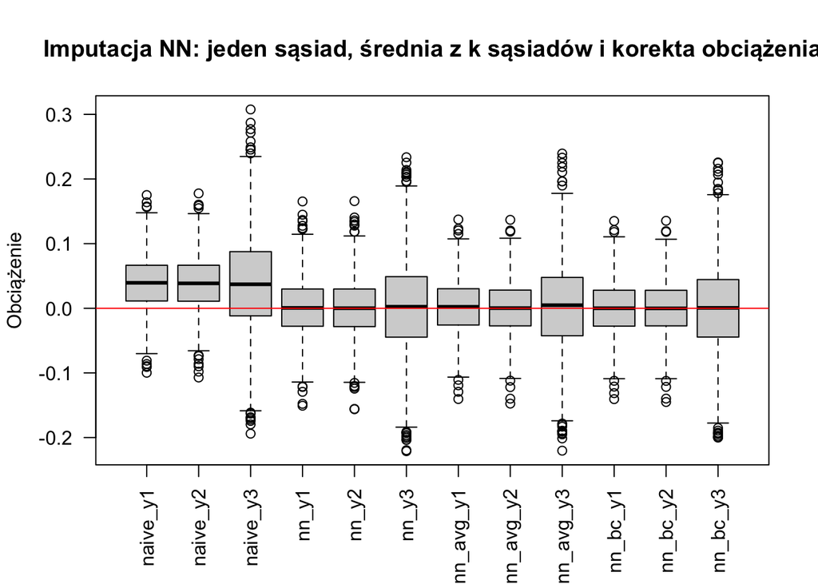

```r
# Ustawienie ziarna losowości dla reprodukowalności
set.seed(123)

# Parametry symulacji
N <- 50000  # rozmiar populacji
n <- 1000    # rozmiar próby

# Generowanie zmiennych objaśniających
x1 <- runif(N, 0, 1)
x2 <- runif(N, 0, 1)
x3 <- runif(N, 0, 1)
x4 <- rnorm(N, 0, 1)
x5 <- rnorm(N, 0, 1)
x6 <- rnorm(N, 0, 1)
e <- rnorm(N, 0, 1)

# Generowanie zmiennej y dla trzech modeli
y1 <- -1 + x1 + x2 + e
y2 <- -1.167 + x1 + x2 + (x1-0.5)^2 + (x2-0.5)^2 + e
y3 <- -1.5 + x1 + x2 + x3 + x4 + x5 + x6 + e

# Tworzenie wskaźnika odpowiedzi (mechanizm braków danych)
logit_p <- 0.2 + x1 + x2
p <- exp(logit_p)/(1 + exp(logit_p))


# Tworzenie ramki danych
populacja <- data.frame(
 id = 1:N,
 x1 = x1,
 x2 = x2,
 x3 = x3,
 x4 = x4,
 x5 = x5,
 x6 = x6,
 y1 = y1,
 y2 = y2,
 y3 = y3,
 p = p
)
y_true <- colMeans(populacja[, c("y1", "y2", "y3")])

## imputacja średnią z k najbliższych sąsiadów (odległość Gowera, tak jak w impute_knn)
## bc = TRUE: korekta obciążenia na podstawie modelu regresji z wielomianem 2 stopnia
impute_nn_mean <- function(proba, y, xs, k, bc = FALSE) {
  resp <- !is.na(proba[[y]])
  y_resp <- proba[[y]][resp]
  ## macierz k x liczba nierespondentów z numerami wierszy dawców
  nn <- gower::gower_topn(x = proba[!resp, xs], y = proba[resp, xs], n = k)$index
  if (bc) {
    model <- lm(reformulate(sprintf("polym(%s, degree = 2, raw = TRUE)",
                                    paste(xs, collapse = ", ")), response = y),
                data = proba[resp, ])
    mu <- predict(model, proba)
    y_imp <- mu[!resp] + colMeans(matrix((y_resp - mu[resp])[nn], nrow = k))
  } else {
    y_imp <- colMeans(matrix(y_resp[nn], nrow = k))
  }
  proba[[y]][!resp] <- y_imp
  proba[[y]]
}

## symulacja (2000 razy)
R <- 2000
results <- matrix(0, R, 12)
colnames(results) <- paste0(rep(c("naive", "nn", "nn_avg", "nn_bc"), each = 3),
                            rep(c("_y1", "_y2", "_y3"), times=4))

xs_2 <- c("x1", "x2")
xs_6 <- c("x1", "x2", "x3", "x4", "x5", "x6")
k_2 <- floor(n^(2/(2+2))) ## k=31 dla p=2
k_6 <- floor(n^(2/(2+6))) ## k=5 dla p=6

for (r in 1:R) {
  proba <- populacja[sample(1:N, n), ]
  proba$delta <- rbinom(nrow(proba), 1, proba$p)
  proba$y1[proba$delta == 0] <- NA
  proba$y2[proba$delta == 0] <- NA
  proba$y3[proba$delta == 0] <- NA

  results[r, 1:3] <- colMeans(proba[, c(c("y1", "y2", "y3"))], na.rm=T)

  ## najbliższy sąsiad (k=1)
  res_y1_y2 <- impute_knn(proba, y1 + y2  ~ x1 + x2, k=1)
  res_y3 <- impute_knn(proba, y3  ~ x1 + x2 + x3  + x4 + x5 + x6, k=1)
  results[r, 4:6] <- c(mean(res_y1_y2$y1), mean(res_y1_y2$y2), mean(res_y3$y3))

  ## średnia z k najbliższych sąsiadów
  results[r, 7:9] <- c(mean(impute_nn_mean(proba, "y1", xs_2, k_2)),
                       mean(impute_nn_mean(proba, "y2", xs_2, k_2)),
                       mean(impute_nn_mean(proba, "y3", xs_6, k_6)))

  ## średnia z k najbliższych sąsiadów z korektą obciążenia
  results[r, 10:12] <- c(mean(impute_nn_mean(proba, "y1", xs_2, k_2, bc = TRUE)),
                         mean(impute_nn_mean(proba, "y2", xs_2, k_2, bc = TRUE)),
                         mean(impute_nn_mean(proba, "y3", xs_6, k_6, bc = TRUE)))

}

boxplot(results -  matrix(rep(y_true, times = 4), byrow=T, ncol = 12, nrow=R),
        xlab = "", ylab = "Obciążenie",
        main = "Imputacja NN: jeden sąsiad, średnia z k sąsiadów i korekta obciążenia",
        las = 2)
abline(a=0,b=0,col="red")
```

Obciążenie estymatora (x100)

```r
round((colMeans(results) - rep(y_true, times = 4))*100,2)
```

```
 naive_y1  naive_y2  naive_y3     nn_y1     nn_y2     nn_y3 nn_avg_y1 nn_avg_y2
     3.90      3.83      3.77      0.10      0.07      0.24      0.23      0.05
nn_avg_y3  nn_bc_y1  nn_bc_y2  nn_bc_y3
     0.39      0.02      0.01      0.04
```

Wariancja

```r
round(apply(results, 2, var)*100,4)
```

```
 naive_y1  naive_y2  naive_y3     nn_y1     nn_y2     nn_y3 nn_avg_y1 nn_avg_y2
   0.1561    0.1590    0.5613    0.1827    0.1843    0.5064    0.1545    0.1563
nn_avg_y3  nn_bc_y1  nn_bc_y2  nn_bc_y3
   0.4787    0.1544    0.1561    0.4559
```

RMSE

```r
bias <- (colMeans(results) - rep(y_true, times = 4))
round(sqrt(bias^2 + apply(results, 2, var))*100,2)
```

```
 naive_y1  naive_y2  naive_y3     nn_y1     nn_y2     nn_y3 nn_avg_y1 nn_avg_y2
     5.55      5.53      8.39      4.28      4.29      7.12      3.94      3.95
nn_avg_y3  nn_bc_y1  nn_bc_y2  nn_bc_y3
     6.93      3.93      3.95      6.75
```

Błąd Monte Carlo obciążenia (x100). Różnice obciążeń mniejsze niż około dwa takie błędy mogą wynikać z losowości symulacji.

```r
round(sqrt(apply(results, 2, var)/R)*100,3)
```

```
 naive_y1  naive_y2  naive_y3     nn_y1     nn_y2     nn_y3 nn_avg_y1 nn_avg_y2
    0.088     0.089     0.168     0.096     0.096     0.159     0.088     0.088
nn_avg_y3  nn_bc_y1  nn_bc_y2  nn_bc_y3
    0.155     0.088     0.088     0.151
```

**Python**

```python
# Ustawienie ziarna losowości
np.random.seed(123)

# Parametry symulacji
N = 50000  # rozmiar populacji
n = 1000    # rozmiar próby

# Generowanie zmiennych objaśniających
x1 = np.random.uniform(0, 1, N)
x2 = np.random.uniform(0, 1, N)
x3 = np.random.uniform(0, 1, N)
x4 = np.random.normal(0, 1, N)
x5 = np.random.normal(0, 1, N)
x6 = np.random.normal(0, 1, N)
e = np.random.normal(0, 1, N)

# Generowanie zmiennej y dla trzech modeli
y1 = -1 + x1 + x2 + e
y2 = -1.167 + x1 + x2 + (x1-0.5)**2 + (x2-0.5)**2 + e
y3 = -1.5 + x1 + x2 + x3 + x4 + x5 + x6 + e

# Tworzenie wskaźnika odpowiedzi
logit_p = 0.2 + x1 + x2
p = np.exp(logit_p)/(1 + np.exp(logit_p))
# Tworzenie ramki danych
populacja = pd.DataFrame({
   'id': range(N),
   'x1': x1,
   'x2': x2,
   'x3': x3,
   'x4': x4,
   'x5': x5,
   'x6': x6,
   'y1': y1,
   'y2': y2,
   'y3': y3,
   'p': p
})

y_true = populacja[['y1', 'y2', 'y3']].mean()

# Imputacja średnią z k najbliższych sąsiadów (dla k=1: wartość najbliższego sąsiada)
# Dla zmiennych ilościowych odległość Gowera = odległość Manhattan na zmiennych przeskalowanych rozstępem
# bc=True: korekta obciążenia na podstawie modelu regresji z wielomianem 2 stopnia
def impute_nn(proba, y_col, x_cols, k, bc=False):
   obs = proba[y_col].notna().to_numpy()
   X = MinMaxScaler().fit_transform(proba[x_cols])
   nn = NearestNeighbors(n_neighbors=k, metric='manhattan').fit(X[obs])
   idx = nn.kneighbors(X[~obs], return_distance=False)
   y = proba[y_col].to_numpy().copy()
   y_obs = y[obs]
   if bc:
       Z = PolynomialFeatures(degree=2, include_bias=False).fit_transform(proba[x_cols])
       mu = LinearRegression().fit(Z[obs], y_obs).predict(Z)
       y[~obs] = mu[~obs] + (y_obs - mu[obs])[idx].mean(axis=1)
   else:
       y[~obs] = y_obs[idx].mean(axis=1)
   return y

# Symulacja (2000 razy)
R = 2000
results = np.zeros((R, 12))
columns = [f"{t}_{y}" for t in ['naive', 'nn', 'nn_avg', 'nn_bc'] for y in ['y1', 'y2', 'y3']]

xs_2 = ['x1', 'x2']
xs_6 = ['x1', 'x2', 'x3', 'x4', 'x5', 'x6']
k_2 = int(np.floor(n**(2/(2+2)))) # k=31 dla p=2
k_6 = int(np.floor(n**(2/(2+6)))) # k=5 dla p=6

for r in range(R):
   # Losowanie próby
   proba = populacja.sample(n=n)

   # Generowanie braków danych
   delta = np.random.binomial(1, proba['p'])
   proba.loc[delta == 0, ['y1', 'y2', 'y3']] = np.nan

   # Średnie dla metody naiwnej
   results[r, 0:3] = proba[['y1', 'y2', 'y3']].mean()

   # Najbliższy sąsiad (k=1)
   results[r, 3:6] = [impute_nn(proba, 'y1', xs_2, 1).mean(),
                      impute_nn(proba, 'y2', xs_2, 1).mean(),
                      impute_nn(proba, 'y3', xs_6, 1).mean()]

   # Średnia z k najbliższych sąsiadów
   results[r, 6:9] = [impute_nn(proba, 'y1', xs_2, k_2).mean(),
                      impute_nn(proba, 'y2', xs_2, k_2).mean(),
                      impute_nn(proba, 'y3', xs_6, k_6).mean()]

   # Średnia z k najbliższych sąsiadów z korektą obciążenia
   results[r, 9:12] = [impute_nn(proba, 'y1', xs_2, k_2, bc=True).mean(),
                       impute_nn(proba, 'y2', xs_2, k_2, bc=True).mean(),
                       impute_nn(proba, 'y3', xs_6, k_6, bc=True).mean()]

plt.figure(figsize=(10, 6))
bias = results - np.tile(y_true, 4)
plt.boxplot(bias)
```

[output not shown]

```python
plt.axhline(y=0, color='r', linestyle='-')
plt.xlabel('')
plt.ylabel('Obciążenie')
plt.title('Imputacja NN: jeden sąsiad, średnia z k sąsiadów i korekta obciążenia')
plt.xticks(range(1, 13), columns, rotation=90)
```

[output not shown]

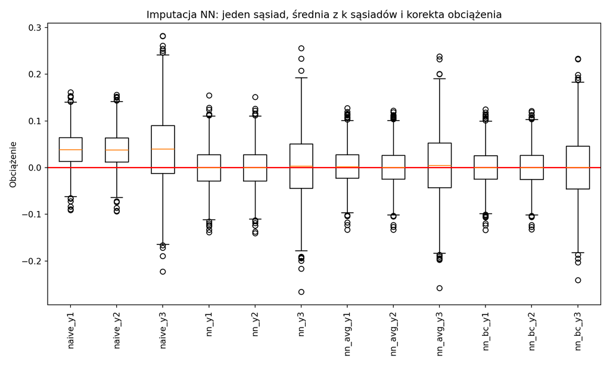

```python
plt.tight_layout()
plt.show()
```

Obciążenie estymatora (x100), wariancja (x100), RMSE (x100) i błąd Monte Carlo obciążenia (x100)

```python
bias = results.mean(axis=0) - np.tile(y_true, 4)
pd.DataFrame({'bias': np.round(bias*100, 2),
              'var': np.round(results.var(axis=0, ddof=1)*100, 4),
              'rmse': np.round(np.sqrt(bias**2 + results.var(axis=0, ddof=1))*100, 2),
              'mc_se': np.round(np.sqrt(results.var(axis=0, ddof=1)/R)*100, 3)},
             index=columns)
```

```
           bias     var  rmse  mc_se
naive_y1   3.85  0.1506  5.46  0.087
naive_y2   3.78  0.1530  5.44  0.087
naive_y3   3.93  0.5671  8.50  0.168
nn_y1     -0.01  0.1770  4.21  0.094
nn_y2     -0.03  0.1786  4.23  0.094
nn_y3      0.41  0.5206  7.23  0.161
nn_avg_y1  0.26  0.1494  3.87  0.086
nn_avg_y2  0.08  0.1509  3.88  0.087
nn_avg_y3  0.53  0.4892  7.01  0.156
nn_bc_y1   0.04  0.1494  3.87  0.086
nn_bc_y2   0.03  0.1508  3.88  0.087
nn_bc_y3   0.11  0.4661  6.83  0.153
```

# 9 Przykład 2 – Gower

**R**

```r
dane <- data.frame(
   plec = factor(c("K", "M", "K")),                     # zmienna nominalna
   wyksztalcenie = factor(                              # zmienna porządkowa
       c("wyższe", "średnie", "podstawowe"),
       levels = c("podstawowe", "średnie", "wyższe"),   # określamy porządek poziomów
       ordered = TRUE
   ),
   wiek = c(25, 35, 45)                                 # zmienna ilorazowa
)
```

```r
VIM::gowerD(data.x = dane,
            factors = "plec",
            numerical = "wiek",
            orders = "wyksztalcenie",
            levOrders = 3)
```

```
          [,1]      [,2]      [,3]
[1,] 0.0000000 0.6666667 0.6666667
[2,] 0.6666667 0.0000000 0.6666667
[3,] 0.6666667 0.6666667 0.0000000
```

```r
## odległość pierwszej obserwacji od wszystkich (rozstęp liczony na całym zbiorze)
gower::gower_dist(x = dane[1, ],
                  y = dane)
```

```
[1] 0.0000000 0.8333333 0.6666667
```

**Python**

```python
dane = pd.DataFrame({
   'plec': pd.Categorical(["K", "M", "K"]),                          # zmienna nominalna
   'wyksztalcenie': pd.Categorical(                                  # zmienna porządkowa
       ["wyższe", "średnie", "podstawowe"],
       categories=["podstawowe", "średnie", "wyższe"],
       ordered=True
   ),
   'wiek': [25, 35, 45]                                             # zmienna ilorazowa
})
```

Pakiet `gower` traktuje zmienną porządkową jak nominalną (tak jak pakiet `gower` w R, inaczej niż `VIM::gowerD`), a zmienne jakościowe muszą być typu `object`.

```python
gower.gower_matrix(dane.astype({'plec': object, 'wyksztalcenie': object}))
```

```
array([[0.       , 0.8333334, 0.6666667],
       [0.8333334, 0.       , 0.8333334],
       [0.6666667, 0.8333334, 0.       ]], dtype=float32)
```

# 10 Przykład 3 – czytelnictwo

Imputujemy `czyta_ksiazki_z_brakami` na podstawie zmiennych `plec`, `wiek` i `wyksztalcenie` (odległość Gowera) i porównujemy wyniki ze znaną prawdziwą wartością (`czyta_ksiazki`).

**R**

```r
## reading
data <- read.csv(file = "../../data/data4-czytelnictwo.csv",
                 colClasses = c("factor", "numeric", "factor", "logical", "logical"))
```

Od czego zależy występowanie braku?

```r
glm(I(is.na(czyta_ksiazki_z_brakami)) ~ plec + wiek + wyksztalcenie,
    data = data, family = binomial()) |>
  summary()
```

```
Call:
glm(formula = I(is.na(czyta_ksiazki_z_brakami)) ~ plec + wiek +
    wyksztalcenie, family = binomial(), data = data)

Coefficients:
                          Estimate Std. Error z value Pr(>|z|)
(Intercept)              0.5465573  0.5758101   0.949  0.34252
plecM                   -0.1932175  0.1575789  -1.226  0.22014
wiek                    -0.0006561  0.0056514  -0.116  0.90758
wyksztalceniepodstawowe -1.1159485  0.5585404  -1.998  0.04572 *
wyksztalcenieśrednie    -1.6148509  0.5381828  -3.001  0.00269 **
wyksztalceniewyższe     -2.4217546  0.5571485  -4.347 1.38e-05 ***
---
Signif. codes:  0 '***' 0.001 '**' 0.01 '*' 0.05 '.' 0.1 ' ' 1

(Dispersion parameter for binomial family taken to be 1)

    Null deviance: 1051.3  on 999  degrees of freedom
Residual deviance: 1008.2  on 994  degrees of freedom
AIC: 1020.2

Number of Fisher Scoring iterations: 4
```

Liczba remisów: ilu dawców leży w minimalnej odległości od biorcy. Wiek jest podany w latach, więc wielu dawców ma dokładnie te same wartości zmiennych co biorca.

```r
xs <- c("plec", "wiek", "wyksztalcenie")
resp <- !is.na(data$czyta_ksiazki_z_brakami)
remisy <- sapply(which(!resp), function(i) {
  d <- gower::gower_dist(data[i, xs], data[resp, xs])
  sum(d == min(d))
})
table(remisy)
```

```
remisy
 1  2  3  4  5  6  7  8 10 11 12 13
43 31 47 21 33 11 11  7  5  3  6  1
```

```r
mean(remisy > 1)
```

```
[1] 0.803653
```

Funkcja `impute_knn()` losuje dawcę spośród `k` najbliższych sąsiadów. Przy `k = 1` nie ma losowania, a remis rozstrzyga kolejność dawców w danych, więc ten sam dawca trafia do wszystkich biorców o tych samych wartościach zmiennych. Poniższa funkcja losuje dawcę spośród wszystkich dawców w minimalnej odległości.

```r
impute_nn_ties <- function(dane, y, xs) {
  resp <- !is.na(dane[[y]])
  dawcy <- dane[resp, ]
  dane[[y]][!resp] <- sapply(which(!resp), function(i) {
    d <- gower::gower_dist(dane[i, xs], dawcy[xs])
    kandydaci <- which(d == min(d))
    dawcy[[y]][kandydaci[sample.int(length(kandydaci), 1)]]
  })
  dane[[y]]
}
```

Imputacja i porównanie. Trafność to odsetek biorców, którym przypisano prawdziwą wartość.

```r
set.seed(2025)
f <- czyta_ksiazki_z_brakami ~ plec + wiek + wyksztalcenie
## k = 1: przy remisie wybierany jest pierwszy dawca w kolejności danych
wynik_nn1 <- impute_knn(data, f, k = 1)$czyta_ksiazki_z_brakami
## k = 1: dawca losowany spośród remisów
wynik_nn1_los <- impute_nn_ties(data, "czyta_ksiazki_z_brakami", xs)
## k = 5: dawca losowany spośród 5 najbliższych sąsiadów
wynik_nn5 <- impute_knn(data, f, k = 5)$czyta_ksiazki_z_brakami
## k = 5: dominanta wartości 5 najbliższych sąsiadów (pakiet VIM)
wynik_nn5_dom <- kNN(data, variable = "czyta_ksiazki_z_brakami", dist_var = xs,
                     k = 5, imp_var = FALSE)$czyta_ksiazki_z_brakami

wyniki <- list(`k = 1` = wynik_nn1,
               `k = 1, remisy losowo` = wynik_nn1_los,
               `k = 5, dawca losowy` = wynik_nn5,
               `k = 5, dominanta` = wynik_nn5_dom)

data.frame(
  metoda = c("prawda", "respondenci", names(wyniki)),
  srednia = c(mean(data$czyta_ksiazki),
              mean(data$czyta_ksiazki_z_brakami, na.rm = TRUE),
              sapply(wyniki, mean)),
  trafnosc = c(NA, NA, sapply(wyniki, function(w) mean(w[!resp] == data$czyta_ksiazki[!resp]))),
  row.names = NULL
)
```

```
                metoda   srednia  trafnosc
1               prawda 0.7200000        NA
2          respondenci 0.7298335        NA
3                k = 1 0.6960000 0.5251142
4 k = 1, remisy losowo 0.7070000 0.6210046
5  k = 5, dawca losowy 0.7110000 0.6118721
6     k = 5, dominanta 0.7240000 0.6803653
```

Wynik jednej imputacji losowej zależy od ziarna. Powtarzamy imputację z `k = 5` dla 100 losowań.

```r
srednie_nn5 <- replicate(100, mean(impute_knn(data, f, k = 5)$czyta_ksiazki_z_brakami))
summary(srednie_nn5)
```

```
   Min. 1st Qu.  Median    Mean 3rd Qu.    Max.
 0.6940  0.7070  0.7100  0.7102  0.7140  0.7240
```

**Python**

```python
data = pd.read_csv("../../data/data4-czytelnictwo.csv",
                   dtype={'plec': 'category',
                          'wiek': 'float64',
                          'wyksztalcenie': 'category',
                          'czyta_ksiazki': 'float64',
                          'czyta_ksiazki_z_brakami': 'float64'})

y = 'czyta_ksiazki_z_brakami'
xs = ['plec', 'wiek', 'wyksztalcenie']
resp = data[y].notna().to_numpy()
y_resp = data.loc[resp, y].to_numpy()
```

Macierz odległości Gowera (wiersze – biorcy, kolumny – dawcy) i liczba remisów: ilu dawców leży w minimalnej odległości od biorcy.

```python
X = data[xs].astype({'plec': object, 'wyksztalcenie': object})
D = gower.gower_matrix(X[~resp], X[resp])

remisy = (D == D.min(axis=1, keepdims=True)).sum(axis=1)
print(pd.Series(remisy).value_counts().sort_index())
```

```
1     43
2     31
3     47
4     21
5     33
6     11
7     11
8      7
10     5
11     3
12     6
13     1
Name: count, dtype: int64
```

```python
(remisy > 1).mean()
```

```
np.float64(0.8036529680365296)
```

Imputacja i porównanie. Trafność to odsetek biorców, którym przypisano prawdziwą wartość. `KNNImputer` z `sklearn` wstawia średnią z `k` sąsiadów (tu wartość ułamkową, więc trafności nie liczymy) i stosuje odległość euklidesową, dlatego zmienne jakościowe zamieniamy na zero-jedynkowe, a wiek skalujemy do przedziału [0, 1].

```python
rng = np.random.default_rng(2025)
# dawcy uporządkowani od najbliższego; przy remisie decyduje kolejność w danych
kolejnosc = np.argsort(D, axis=1, kind='stable')
biorcy = np.arange(D.shape[0])

imputacje = {
    # k = 1: pierwszy dawca w kolejności danych
    'k = 1': y_resp[kolejnosc[:, 0]],
    # k = 1: dawca losowany spośród remisów
    'k = 1, remisy losowo': np.array([rng.choice(y_resp[D[i] == D[i].min()]) for i in biorcy]),
    # k = 5: dawca losowany spośród 5 najbliższych
    'k = 5, dawca losowy': y_resp[kolejnosc[biorcy, rng.integers(0, 5, len(biorcy))]],
    # k = 5: dominanta wartości 5 najbliższych (przy nieparzystym k nie ma remisu)
    'k = 5, dominanta': (y_resp[kolejnosc[:, :5]].mean(axis=1) > 0.5).astype(float),
}

Z = pd.get_dummies(data[['plec', 'wyksztalcenie']]).astype(float)
Z['wiek'] = (data['wiek'] - data['wiek'].min()) / (data['wiek'].max() - data['wiek'].min())
Z[y] = data[y]
knn_srednia = KNNImputer(n_neighbors=5).fit_transform(Z)[~resp, -1]

prawda = data.loc[~resp, 'czyta_ksiazki'].to_numpy()
pd.DataFrame({
    'srednia': [data['czyta_ksiazki'].mean(), data[y].mean()] +
               [(y_resp.sum() + v.sum()) / len(data) for v in imputacje.values()] +
               [(y_resp.sum() + knn_srednia.sum()) / len(data)],
    'trafnosc': [np.nan, np.nan] + [np.mean(v == prawda) for v in imputacje.values()] + [np.nan]
}, index=['prawda', 'respondenci'] + list(imputacje.keys()) + ['k = 5, średnia (KNNImputer)']).round(3)
```

```
                             srednia  trafnosc
prawda                         0.720       NaN
respondenci                    0.730       NaN
k = 1                          0.696     0.525
k = 1, remisy losowo           0.706     0.571
k = 5, dawca losowy            0.710     0.635
k = 5, dominanta               0.722     0.680
k = 5, średnia (KNNImputer)    0.704       NaN
```

Uwaga: warianty losowe dają inne wyniki niż w R, bo inny jest generator liczb losowych. Warianty bez losowania (`k = 1` i dominanta) dają te same średnie co w R z dokładnością do sposobu rozstrzygania remisów.